# Examples of map layers

# bw-mapnik

`plot(openmap(x,path="bw-mapnik"))`

© [OpenStreetMap](http://openstreetmap.org/copyright) contributors. Data by [OpenStreetMap](http://openstreetmap.org), available under the [Open Database License](http://opendatacommons.org/licenses/odbl), cartography is licensed as [CC BY-SA](http://creativecommons.org/licenses/by-sa/2.0).

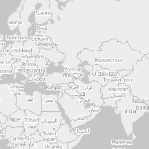

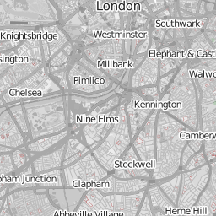

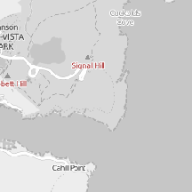

# osm-cyclemap

`plot(openmap(x,path="osm-cyclemap"))`

© [OpenStreetMap](http://openstreetmap.org/copyright) contributors. Data by [OpenStreetMap](http://openstreetmap.org), available under the [Open Database License](http://opendatacommons.org/licenses/odbl), cartography is licensed as [CC BY-SA](http://creativecommons.org/licenses/by-sa/2.0).

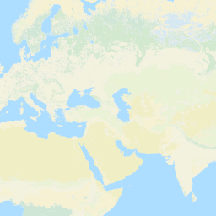

[figure not shown]

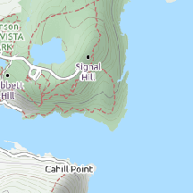

# osm-seamap

`plotRGB(openmap(x,path="osm-seamap"))`

© [OpenStreetMap](http://openstreetmap.org/copyright) contributors. Data by [OpenStreetMap](http://openstreetmap.org), available under the [Open Database License](http://opendatacommons.org/licenses/odbl), cartography is licensed as [CC BY-SA](http://creativecommons.org/licenses/by-sa/2.0).

[figure not shown]

# osm-fr

`plot(openmap(x,path="osm-fr"))`

© [OpenStreetMap](http://openstreetmap.org/copyright) contributors. Data by [OpenStreetMap](http://openstreetmap.org), available under the [Open Database License](http://opendatacommons.org/licenses/odbl), cartography is licensed as [CC BY-SA](http://creativecommons.org/licenses/by-sa/2.0).

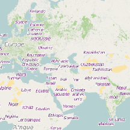

[figure not shown]

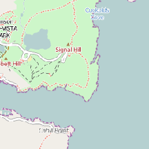

# landscape

`plot(openmap(x,path="landscape"))`

© [OpenStreetMap](http://openstreetmap.org/copyright) contributors. Data by [OpenStreetMap](http://openstreetmap.org), available under the [Open Database License](http://opendatacommons.org/licenses/odbl), cartography by [Thunderforest](http://www.thunderforest.com/)

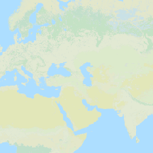

[figure not shown]

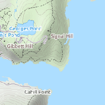

# hyda

`plot(openmap(x,path="hyda"))`

© [OpenStreetMap](http://openstreetmap.org/copyright) contributors. Data by [OpenStreetMap](http://openstreetmap.org), available under the [Open Database License](http://opendatacommons.org/licenses/odbl), cartography is licensed as [CC BY-SA](http://creativecommons.org/licenses/by-sa/2.0).

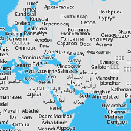

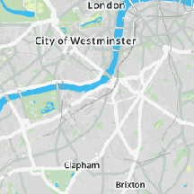

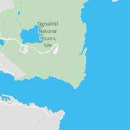

# hyda-base

`plot(openmap(x,path="hyda-base"))`

© [OpenStreetMap](http://openstreetmap.org/copyright) contributors. Data by [OpenStreetMap](http://openstreetmap.org), available under the [Open Database License](http://opendatacommons.org/licenses/odbl), cartography is licensed as [CC BY-SA](http://creativecommons.org/licenses/by-sa/2.0).

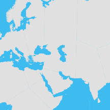

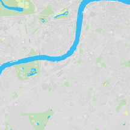

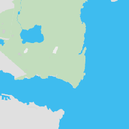

# hyda-roads

`plot(openmap(x,path="hyda-roads"))`

© [OpenStreetMap](http://openstreetmap.org/copyright) contributors. Data by [OpenStreetMap](http://openstreetmap.org), available under the [Open Database License](http://opendatacommons.org/licenses/odbl), cartography is licensed as [CC BY-SA](http://creativecommons.org/licenses/by-sa/2.0).

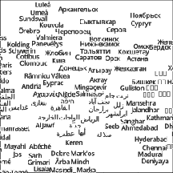

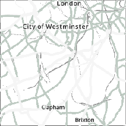

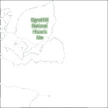

# opentopomap

`plot(openmap(x,path="opentopomap"))`

© [OpenStreetMap](http://openstreetmap.org/copyright) contributors. Data by [OpenStreetMap](http://openstreetmap.org), available under the [Open Database License](http://opendatacommons.org/licenses/odbl), cartography is licensed as [CC BY-SA](http://creativecommons.org/licenses/by-sa/2.0).

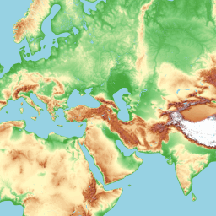

[figure not shown]

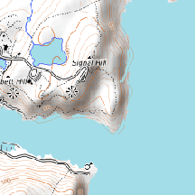

# maptoolkit

`plot(openmap(x,path="maptoolkit"))`

© [Toursprung GmbH](http://www.toursprung.com) Data by [OpenStreetMap](http://openstreetmap.org), available under the [Open Database License](http://opendatacommons.org/licenses/odbl)

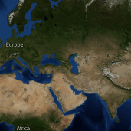

[figure not shown]

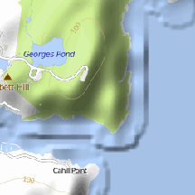

# waze

`plotRGB(openmap(x,path="waze"))`

© [Waze mobile](http://www.waze.com/legal/notices)

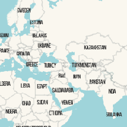

[figure not shown]

# waze-us

`plotRGB(openmap(x,path="waze-us"))`

© [Waze mobile](http://www.waze.com/legal/notices)

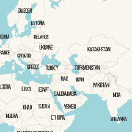

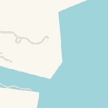

# humanitarian

`plot(openmap(x,path="humanitarian"))`

© [OpenStreetMap](http://openstreetmap.org/copyright) contributors. Data by [OpenStreetMap](http://openstreetmap.org), available under the [Open Database License](http://opendatacommons.org/licenses/odbl), cartography by [Humanitarian OSM team](http://hot.openstreetmap.org/about) is licensed as [CC BY-SA](http://creativecommons.org/licenses/by-sa/2.0).

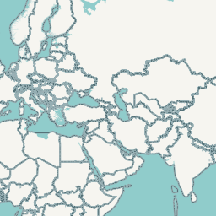

[figure not shown]

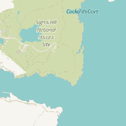

# cartodb

`plot(openmap(x,path="cartodb"))`

Map tiles by [CartoDB](http://cartodb.com) under [CC BY 3.0](http://creativecommons.org/licenses/by/3.0). Data by [OpenStreetMap](http://openstreetmap.org), available under the [Open Database License](http://opendatacommons.org/licenses/odbl)

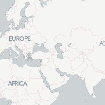

[figure not shown]

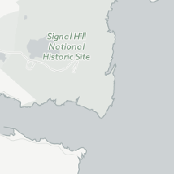

# cartodb-dark

`plot(openmap(x,path="cartodb-dark"))`

Map tiles by [CartoDB](http://cartodb.com) under [CC BY 3.0](http://creativecommons.org/licenses/by/3.0). Data by [OpenStreetMap](http://openstreetmap.org), available under the [Open Database License](http://opendatacommons.org/licenses/odbl)

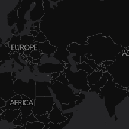

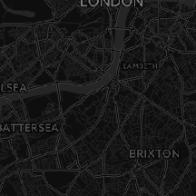

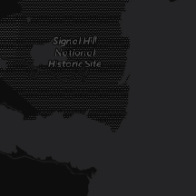

# nrcan

`plotRGB(openmap(x,path="nrcan"))`

Cartography by [The Canada Base Map - Transportation (CBMT) web mapping services of the Earth Sciences Sector (ESS) at Natural Resources Canada (NRCan)](http://www.nrcan.gc.ca/earth-sciences/geography/topographic-information/free-data-geogratis/geogratis-web-services/17216) licensed as the [Open Government Licence - Canada](http://open.canada.ca/en/open-government-licence-canada).

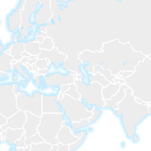

[figure not shown]

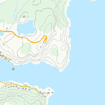

# nrcan-text

`plotRGB(openmap(x,path="nrcan-text"))`

Cartography by [The Canada Base Map - Transportation (CBMT) web mapping services of the Earth Sciences Sector (ESS) at Natural Resources Canada (NRCan)](http://www.nrcan.gc.ca/earth-sciences/geography/topographic-information/free-data-geogratis/geogratis-web-services/17216) licensed as the [Open Government Licence - Canada](http://open.canada.ca/en/open-government-licence-canada).

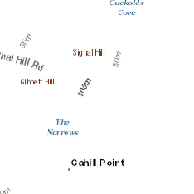

# nrcan-text-fr

`plotRGB(openmap(x,path="nrcan-text-fr"))`

Cartography by [The Canada Base Map - Transportation (CBMT) web mapping services of the Earth Sciences Sector (ESS) at Natural Resources Canada (NRCan)](http://www.nrcan.gc.ca/earth-sciences/geography/topographic-information/free-data-geogratis/geogratis-web-services/17216) licensed as the [Open Government Licence - Canada](http://open.canada.ca/en/open-government-licence-canada).

[figure not shown]

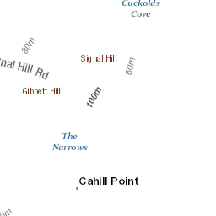

# spinal

`plot(openmap(x,path="spinal"))`

Map tiles by [Thunderforest](http://thunderforest.com) under [CC BY 3.0](http://creativecommons.org/licenses/by/3.0). Data by [OpenStreetMap](http://openstreetmap.org), available under the [Open Database License](http://opendatacommons.org/licenses/odbl)

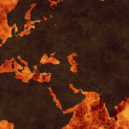

[figure not shown]

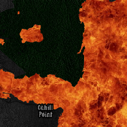

# neighbourhood

`plot(openmap(x,path="neighbourhood"))`

Map tiles by [Thunderforest](http://thunderforest.com) under [CC BY 3.0](http://creativecommons.org/licenses/by/3.0). Data by [OpenStreetMap](http://openstreetmap.org), available under the [Open Database License](http://opendatacommons.org/licenses/odbl)

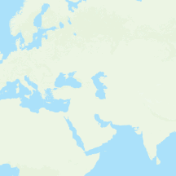

[figure not shown]

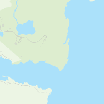

# pioneer

`plot(openmap(x,path="pioneer"))`

Map tiles by [Thunderforest](http://thunderforest.com) under [CC BY 3.0](http://creativecommons.org/licenses/by/3.0). Data by [OpenStreetMap](http://openstreetmap.org), available under the [Open Database License](http://opendatacommons.org/licenses/odbl)

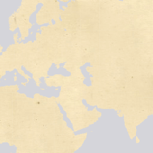

[figure not shown]

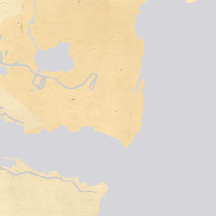

# mobile-atlas

`plot(openmap(x,path="mobile-atlas"))`

Map tiles by [Thunderforest](http://thunderforest.com) under [CC BY 3.0](http://creativecommons.org/licenses/by/3.0). Data by [OpenStreetMap](http://openstreetmap.org), available under the [Open Database License](http://opendatacommons.org/licenses/odbl)

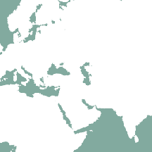

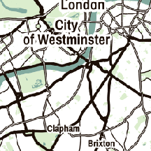

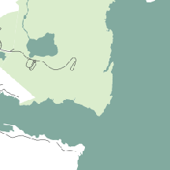

# wikimedia

`plotRGB(openmap(x,path="wikimedia"))`

© [OpenStreetMap](http://openstreetmap.org/copyright) contributors. Data by [OpenStreetMap](http://openstreetmap.org), available under the [Open Database License](http://opendatacommons.org/licenses/odbl), cartography is licensed as [CC BY-SA](http://creativecommons.org/licenses/by-sa/2.0).

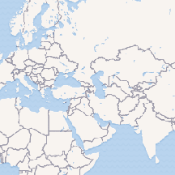

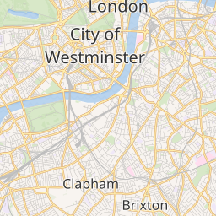

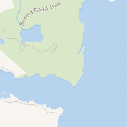

# sputnik

`plot(openmap(x,path="sputnik"))`

corp.sputnik.ru/maps.

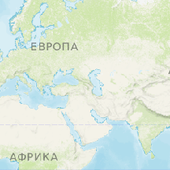

[figure not shown]

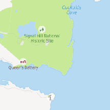

# stamen-toner

`plotRGB(openmap(x,path="stamen-toner"))`

Map tiles by [Stamen Design](http://stamen.com) under [CC BY 3.0](http://creativecommons.org/licenses/by/3.0). Data by [OpenStreetMap](http://openstreetmap.org), available under the [Open Database License](http://opendatacommons.org/licenses/odbl)

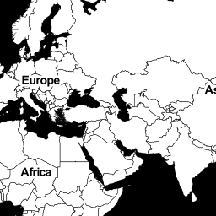

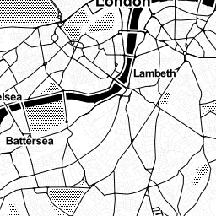

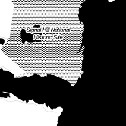

# stamen-watercolor

`plotRGB(openmap(x,path="stamen-watercolor"))`

Map tiles by [Stamen Design](http://stamen.com) under [CC BY 3.0](http://creativecommons.org/licenses/by/3.0). Data by [OpenStreetMap](http://openstreetmap.org), available under the [CC BY-SA](http://creativecommons.org/licenses/by/3.0)

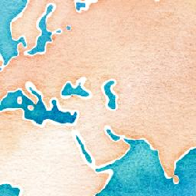

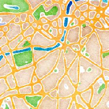

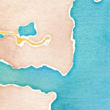

# stamen-terrain

`plot(openmap(x,path="stamen-terrain"))`

Map tiles by [Stamen Design](http://stamen.com) under [CC BY 3.0](http://creativecommons.org/licenses/by/3.0). Data by [OpenStreetMap](http://openstreetmap.org), available under the [CC BY-SA](http://creativecommons.org/licenses/by/3.0)

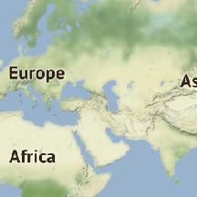

[figure not shown]

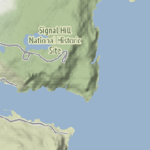

# stamen-terrain-labels

`plotRGB(openmap(x,path="stamen-terrain-labels"))`

Map tiles by [Stamen Design](http://stamen.com) under [CC BY 3.0](http://creativecommons.org/licenses/by/3.0). Data by [OpenStreetMap](http://openstreetmap.org), available under the [CC BY-SA](http://creativecommons.org/licenses/by/3.0)

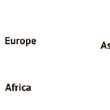

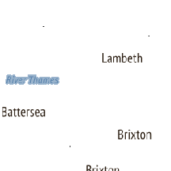

[figure not shown]

# stamen-terrain-background

`plot(openmap(x,path="stamen-terrain-background"))`

Map tiles by [Stamen Design](http://stamen.com) under [CC BY 3.0](http://creativecommons.org/licenses/by/3.0). Data by [OpenStreetMap](http://openstreetmap.org), available under the [CC BY-SA](http://creativecommons.org/licenses/by/3.0)

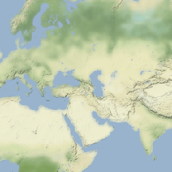

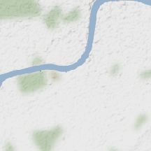

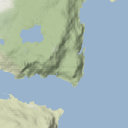